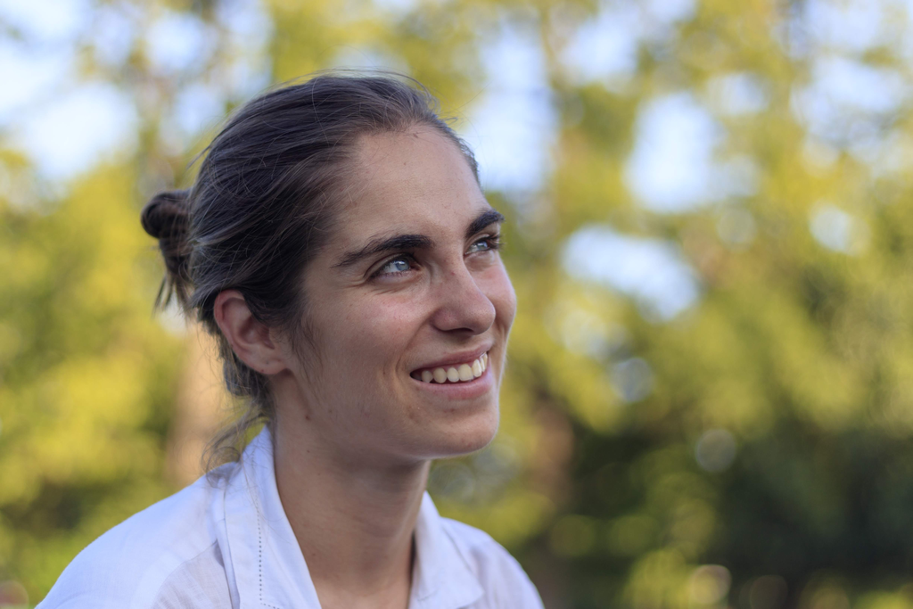

# Marguerite Obolensky

Welcome! I am a PhD candidate in the [Sustainable Development program](https://www.sipa.columbia.edu/academics/programs/phd-sustainable-development) at Columbia University’s School of International and Public Affairs.

I work on questions in environmental economics and climate change adaptation using tools from empirical industrial organization.

I hold a Master’s degree in Environmental Economics and Climate Change from the London School of Economics and a Bachelor’s degree from Ecole Polytechnique, France. Prior to my PhD, I worked as a consultant in disaster risk management at the World Bank.

I am on the 2024-2025 job market.

## Research

**Homeward Bound: How Migrants Seek Out Familiar Climates [New Draft Coming Soon]**  
with Marco Tabellini and Charles Taylor

[nber](https://www.nber.org/papers/w32035?utm_campaign=ntwh&utm_medium=email&utm_source=ntwg18) / [vox](https://cepr.org/voxeu/columns/homeward-bound-how-migrants-seek-out-familiar-climates) /

**Protect or Prepare: Designing Crop Insurance Subsidies for a Changing Climate [JMP]**

**Local Crop Species Diversity and Pest Diffusion: Evidence from the US Census of Agriculture**  
with Tristan du Puy

**News Media Concentration and Content Diversity**  
with Pierre Bodéré and Nicolas Longuet Marx

## Pre-Doctoral Work

**Wading Out the Storm: The Role of Poverty in Exposure, Vulnerability and Resilience to Floods in Dar Es Salaam**  
with Alvina Erman, Mersedeh Tariverdi, Xiaomeng Chen, Rose Vincent, Silvia Malgioglio, Jun Rentschler, Stéphane Hallegatte, Nobuo Yoshida

[paper](https://papers.ssrn.com/sol3/papers.cfm?abstract_id=3436477) /

**Candle in the Wind? Energy System Resilience to Natural Shocks**  
with Jun Rentschler and Martin Kornejew

[paper](https://papers.ssrn.com/sol3/papers.cfm?abstract_id=3430507) /

**Underutilized Potential: The Business Costs of Unreliable Infrastructure in Developing Countries**  
with Jun Rentschler, Martin Kornejew, Stéphane Hallegatte and Johannes Braese

[paper](https://papers.ssrn.com/sol3/papers.cfm?abstract_id=3430509) /

**Infrastructure Disruptions: How Instability Breeds Household Vulnerability**  
with Alvina Erman, Julie Rozenberg, Jun Rentschler, Paolo Avner and Stéphane Hallegatte

[paper](https://papers.ssrn.com/sol3/papers.cfm?abstract_id=3430512) /